# RTSA SS23: Exercise Sheet 7

Martin Memmesheimer

Pranaya Tomar

05.06.2023

**FEEDBACK**

Leave this as it is, we fill it out while grading.

# Exercise 7.2

```r
df <- read.csv("mygardens.txt", header=TRUE, sep='\t')
ozone = df$ozone
garden = df$garden
N = length(ozone)
```

## Part (a)

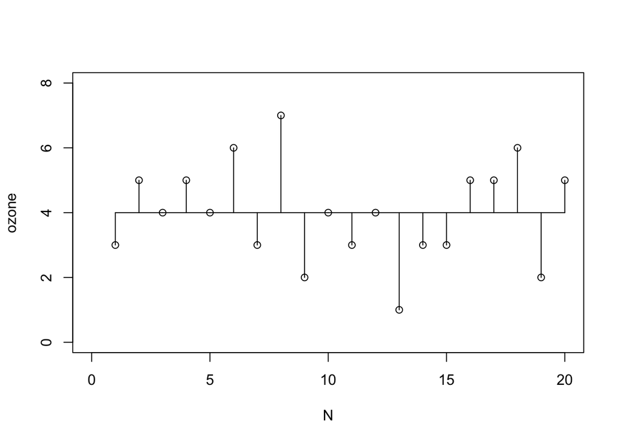

```r
plot(1:N, ozone, xlab="N", ylab="ozone", xlim=c(0, N), ylim=c(0, max(ozone)+1))
mean_overall = mean(ozone)
lines(1:N, matrix(mean_overall, N, 1))
for(i in 1:N) {
  segments(i, mean_overall, i, ozone[i])
}
```

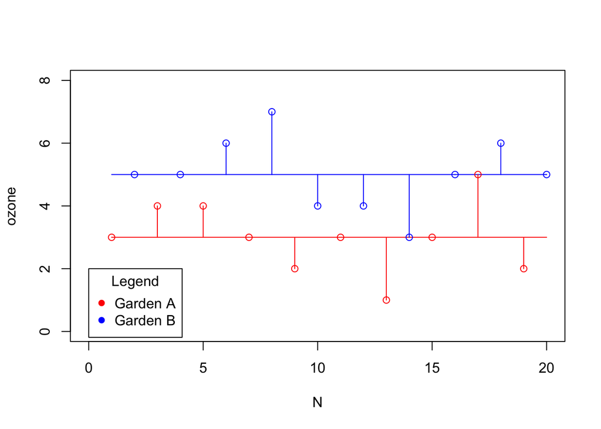

```r
df_a = df[df$garden == 'A',]
df_b = df[df$garden == 'B',]
ozone_a = df_a$ozone
ozone_b = df_b$ozone
mean_a = mean(ozone_a)
mean_b = mean(ozone_b)

plot(1, type="n", xlab="N", ylab="ozone", xlim=c(0, N), ylim=c(0, max(ozone)+1))
lines(1:N, matrix(mean_a, N, 1), col='red')
lines(1:N, matrix(mean_b, N, 1), col='blue')
for(i in 1:N){
  if (df$garden[i] == 'A') {
    points(i, df$ozone[i], col='red')
    segments(i, mean_a, i, df$ozone[i], col='red')
  } else {
    points(i, df$ozone[i], col='blue')
    segments(i, mean_b, i, df$ozone[i], col='blue')
  }
}
legend(0, 2, inset = .05, legend=c("Garden A", "Garden B"), col=c("red","blue"), pch=c(16,16), bg=c("white","white"), title="Legend")
```

## Part (b)

```r
D_b_hat = length(ozone_a)*(mean_a - mean_overall)^2 + length(ozone_b)*(mean_b - mean_overall)^2
print(c('D_b_hat = ', D_b_hat))
```

```
## [1] "D_b_hat = " "20"
```

```r
D_i_hat = sum((ozone_a - mean_a)^2) + sum((ozone_b - mean_b)^2)
print(c('D_i_hat = ', D_i_hat))
```

```
## [1] "D_i_hat = " "24"
```

```r
D_g_hat = D_b_hat + D_i_hat
print(c('D_g_hat = ', D_g_hat))
```

```
## [1] "D_g_hat = " "44"
```

```r
p = 2
R = ((N-p)/(p-1))*(D_b_hat/D_i_hat)
print(R)
```

```
## [1] 15
```

```r
if (R>qf(0.95,p-1,N-p)) {
  print('There is a significant difference between gardens A and B wrt ozone concentration at significance level 0.05')
}
```

```
## [1] "There is a significant difference between gardens A and B wrt ozone concentration at significance level 0.05"
```

## Part (c)

```r
anova = aov(ozone~garden, data = df)
print(summary.aov(anova))
```

```
##             Df Sum Sq Mean Sq F value  Pr(>F)
## garden       1     20  20.000      15 0.00111 **
## Residuals   18     24   1.333
## ---
## Signif. codes:  0 '***' 0.001 '**' 0.01 '*' 0.05 '.' 0.1 ' ' 1
```

# Exercise 7.3

```r
data <- read.csv("bodyfat.csv")
data$Height <- data$Height * 0.0254
data$Weight <- data$Weight * 0.45359237
```

## Part (a)

```r
cor_mat <- cor(cbind(data))
cor_mat
```

```
##             Density     BodyFat         Age      Weight      Height       Neck
## Density  1.00000000 -0.98778240 -0.27763721 -0.59406188  0.09788114 -0.4729664
## BodyFat -0.98778240  1.00000000  0.29145844  0.61241400 -0.08949538  0.4905919
## Age     -0.27763721  0.29145844  1.00000000 -0.01274609 -0.17164514  0.1135052
## Weight  -0.59406188  0.61241400 -0.01274609  1.00000000  0.30827854  0.8307162
## Height   0.09788114 -0.08949538 -0.17164514  0.30827854  1.00000000  0.2537099
## Neck    -0.47296636  0.49059185  0.11350519  0.83071622  0.25370988  1.0000000
## Chest   -0.68259865  0.70262034  0.17644968  0.89419052  0.13489181  0.7848350
## Abdomen -0.79895463  0.81343228  0.23040942  0.88799494  0.08781291  0.7540774
## Hip     -0.60933143  0.62520092 -0.05033212  0.94088412  0.17039426  0.7349579
## Thigh   -0.55309098  0.55960753 -0.20009576  0.86869354  0.14843561  0.6956973
## Knee    -0.49504035  0.50866524  0.01751569  0.85316739  0.28605321  0.6724050
## Ankle   -0.26489003  0.26596977 -0.10505810  0.61368542  0.26474369  0.4778924
## Biceps  -0.48710872  0.49327113 -0.04116212  0.80041593  0.20781557  0.7311459
## Forearm -0.35164842  0.36138690 -0.08505555  0.63030143  0.22864922  0.6236603
## Wrist   -0.32571598  0.34657486  0.21353062  0.72977489  0.32206533  0.7448264
##              Chest     Abdomen         Hip      Thigh        Knee      Ankle
## Density -0.6825987 -0.79895463 -0.60933143 -0.5530910 -0.49504035 -0.2648900
## BodyFat  0.7026203  0.81343228  0.62520092  0.5596075  0.50866524  0.2659698
## Age      0.1764497  0.23040942 -0.05033212 -0.2000958  0.01751569 -0.1050581
## Weight   0.8941905  0.88799494  0.94088412  0.8686935  0.85316739  0.6136854
## Height   0.1348918  0.08781291  0.17039426  0.1484356  0.28605321  0.2647437
## Neck     0.7848350  0.75407737  0.73495788  0.6956973  0.67240498  0.4778924
## Chest    1.0000000  0.91582767  0.82941992  0.7298586  0.71949640  0.4829879
## Abdomen  0.9158277  1.00000000  0.87406618  0.7666239  0.73717888  0.4532227
## Hip      0.8294199  0.87406618  1.00000000  0.8964098  0.82347262  0.5583868
## Thigh    0.7298586  0.76662393  0.89640979  1.0000000  0.79917030  0.5397971
## Knee     0.7194964  0.73717888  0.82347262  0.7991703  1.00000000  0.6116082
## Ankle    0.4829879  0.45322269  0.55838682  0.5397971  0.61160820  1.0000000
## Biceps   0.7279075  0.68498272  0.73927252  0.7614774  0.67870883  0.4848545
## Forearm  0.5801727  0.50331609  0.54501412  0.5668422  0.55589819  0.4190500
## Wrist    0.6601623  0.61983243  0.63008954  0.5586848  0.66450729  0.5661946
##              Biceps     Forearm      Wrist
## Density -0.48710872 -0.35164842 -0.3257160
## BodyFat  0.49327113  0.36138690  0.3465749
## Age     -0.04116212 -0.08505555  0.2135306
## Weight   0.80041593  0.63030143  0.7297749
## Height   0.20781557  0.22864922  0.3220653
## Neck     0.73114592  0.62366027  0.7448264
## Chest    0.72790748  0.58017273  0.6601623
## Abdomen  0.68498272  0.50331609  0.6198324
## Hip      0.73927252  0.54501412  0.6300895
## Thigh    0.76147745  0.56684218  0.5586848
## Knee     0.67870883  0.55589819  0.6645073
## Ankle    0.48485454  0.41904999  0.5661946
## Biceps   1.00000000  0.67825513  0.6321264
## Forearm  0.67825513  1.00000000  0.5855883
## Wrist    0.63212642  0.58558825  1.0000000
```

From looking at the matrix and saying something is highly correlated if the absolute value of the correlation is larger 0.9 one observes the pairs (Density, BodyFat), (Abdomen, Chest) and (Hip, Weight) are extremely correlated. One might also observe that Weight has a high correlation (>0.8) to almost half of the variables and it is noticeable that Abdomen has the highest correlation to BodyFat excluding density which is very interesting since we try to predict the body fat.

## Part (b)

I choose Abdomen as a starting point because of its high correlation with BodyFat. Furthermore, i tested with and without the intercept.

```r
model <- lm(data$BodyFat ~ data$Abdomen)
summary(model)
```

```
##
## Call:
## lm(formula = data$BodyFat ~ data$Abdomen)
##
## Residuals:
##      Min       1Q   Median       3Q      Max
## -19.0160  -3.7557   0.0554   3.4215  12.9007
##
## Coefficients:
##               Estimate Std. Error t value Pr(>|t|)
## (Intercept)  -39.28018    2.66034  -14.77   <2e-16 ***
## data$Abdomen   0.63130    0.02855   22.11   <2e-16 ***
## ---
## Signif. codes:  0 '***' 0.001 '**' 0.01 '*' 0.05 '.' 0.1 ' ' 1
##
## Residual standard error: 4.877 on 250 degrees of freedom
## Multiple R-squared:  0.6617, Adjusted R-squared:  0.6603
## F-statistic: 488.9 on 1 and 250 DF,  p-value: < 2.2e-16
```

```r
model2 <- lm(data$BodyFat ~ data$Abdomen - 1)
summary(model2)
```

```
##
## Call:
## lm(formula = data$BodyFat ~ data$Abdomen - 1)
##
## Residuals:
##      Min       1Q   Median       3Q      Max
## -15.2429  -5.3291  -0.5287   4.4420  21.5450
##
## Coefficients:
##              Estimate Std. Error t value Pr(>|t|)
## data$Abdomen 0.212571   0.004503   47.21   <2e-16 ***
## ---
## Signif. codes:  0 '***' 0.001 '**' 0.01 '*' 0.05 '.' 0.1 ' ' 1
##
## Residual standard error: 6.66 on 251 degrees of freedom
## Multiple R-squared:  0.8988, Adjusted R-squared:  0.8984
## F-statistic:  2229 on 1 and 251 DF,  p-value: < 2.2e-16
```

From the Adjusted R-squared statistic i decided to proceed without the intercept. From now on I test the model always with every possible new variable and compare the Multiple/Adjusted R-squared from the more complex model with the old model. Selection of a new parameter or stopping will be done by hand and not by a predefined algorithm. One more criteria for stopping is the significance of the individual parameters.

```r
adjusted_R <- function(new_variable) {
  model2 <- lm(data$BodyFat ~ data$Abdomen - 1 + data[,new_variable])
  print(new_variable)
  print(summary(model2)$r.squared)
  print(summary(model2)$adj.r.squared)
}

#summary(lm(data$BodyFat ~ data$Abdomen  + data$Wrist + data$Hip - 1))

col_names <- colnames(data)
col_names <- col_names[! col_names %in% c("BodyFat", "Density", "Abdomen")]

x <- sapply(col_names, adjusted_R)
```

```
## [1] "Age"
## [1] 0.898787
## [1] 0.8979773
## [1] "Weight"
## [1] 0.8989035
## [1] 0.8980947
## [1] "Height"
## [1] 0.9489793
## [1] 0.9485711
## [1] "Neck"
## [1] 0.9489312
## [1] 0.9485227
## [1] "Chest"
## [1] 0.9360157
## [1] 0.9355038
```

[output cut: 21 more lines]

The addition of Wrist raises the R-squared values from 0.89 to 0.95. A look in the summary shows that the parameter is also extremely significant. So I add it to the model and do the same tests.

```r
summary(lm(data$BodyFat ~ data$Abdomen + data$Wrist - 1))
```

```
##
## Call:
## lm(formula = data$BodyFat ~ data$Abdomen + data$Wrist - 1)
##
## Residuals:
##      Min       1Q   Median       3Q      Max
## -17.5277  -3.1524  -0.2089   3.2616  11.9279
##
## Coefficients:
##              Estimate Std. Error t value Pr(>|t|)
## data$Abdomen  0.76609    0.03344   22.91   <2e-16 ***
## data$Wrist   -2.83785    0.17068  -16.63   <2e-16 ***
## ---
## Signif. codes:  0 '***' 0.001 '**' 0.01 '*' 0.05 '.' 0.1 ' ' 1
##
## Residual standard error: 4.599 on 250 degrees of freedom
## Multiple R-squared:  0.9519, Adjusted R-squared:  0.9516
## F-statistic:  2476 on 2 and 250 DF,  p-value: < 2.2e-16
```

```r
adjusted_R <- function(new_variable) {
  model2 <- lm(data$BodyFat ~ data$Abdomen + data$Wrist - 1 + data[,new_variable])
  print(new_variable)
  print(summary(model2)$r.squared)
  print(summary(model2)$adj.r.squared)
}

col_names <- col_names[! col_names %in% c("Wrist")]

x <- sapply(col_names, adjusted_R)
```

```
## [1] "Age"
## [1] 0.9544798
## [1] 0.9539314
## [1] "Weight"
## [1] 0.9535459
## [1] 0.9529862
## [1] "Height"
## [1] 0.9539229
## [1] 0.9533677
## [1] "Neck"
## [1] 0.9536477
## [1] 0.9530892
## [1] "Chest"
## [1] 0.9525136
## [1] 0.9519414
```

[output cut: 18 more lines]

Hip raises the R-squared values the most. A look in the summary of the new model shows that still all parameters are extremely significant. So i add Hip to my model.

```r
summary(lm(data$BodyFat ~ data$Abdomen + data$Wrist + data$Hip - 1))
```

```
##
## Call:
## lm(formula = data$BodyFat ~ data$Abdomen + data$Wrist + data$Hip -
##     1)
##
## Residuals:
##      Min       1Q   Median       3Q      Max
## -13.8052  -3.0791  -0.4024   3.3577  10.8481
##
## Coefficients:
##              Estimate Std. Error t value Pr(>|t|)
## data$Abdomen  0.92048    0.04846  18.993  < 2e-16 ***
## data$Wrist   -1.86064    0.28187  -6.601 2.44e-10 ***
## data$Hip     -0.32160    0.07519  -4.277 2.70e-05 ***
## ---
## Signif. codes:  0 '***' 0.001 '**' 0.01 '*' 0.05 '.' 0.1 ' ' 1
##
## Residual standard error: 4.448 on 249 degrees of freedom
## Multiple R-squared:  0.9552, Adjusted R-squared:  0.9547
## F-statistic:  1771 on 3 and 249 DF,  p-value: < 2.2e-16
```

```r
adjusted_R <- function(new_variable) {
  model2 <- lm(data$BodyFat ~ data$Abdomen + data$Wrist + data$Hip - 1 + data[,new_variable])
  print(new_variable)
  print(summary(model2)$r.squared)
  print(summary(model2)$adj.r.squared)
}

col_names <- col_names[! col_names %in% c("Hip")]

x <- sapply(col_names, adjusted_R)
```

```
## [1] "Age"
## [1] 0.9558084
## [1] 0.9550956
## [1] "Weight"
## [1] 0.955798
## [1] 0.9550851
## [1] "Height"
## [1] 0.9559776
## [1] 0.9552676
## [1] "Neck"
## [1] 0.9560855
## [1] 0.9553772
## [1] "Chest"
## [1] 0.9554194
## [1] 0.9547003
## [1] "Thigh"
## [1] 0.9554698
## [1] 0.9547516
## [1] "Knee"
## [1] 0.9552392
## [1] 0.9545173
## [1] "Ankle"
## [1] 0.9552313
## [1] 0.9545093
## [1] "Biceps"
## [1] 0.9553743
## [1] 0.9546545
## [1] "Forearm"
## [1] 0.9556716
## [1] 0.9549567
```

Neck raises both R-squared values a little bit more than the other variables. A look in the summary reveals that the addition of Neck is not extremely signifcant and makes Wrist also less significant. Nevertheless I include Neck in the model as well.

```r
summary(lm(data$BodyFat ~ data$Abdomen + data$Wrist + data$Hip + data$Neck - 1))
```

```
##
## Call:
## lm(formula = data$BodyFat ~ data$Abdomen + data$Wrist + data$Hip +
##     data$Neck - 1)
##
## Residuals:
##      Min       1Q   Median       3Q      Max
## -12.9928  -3.0149  -0.2584   3.2538  11.8763
##
## Coefficients:
##              Estimate Std. Error t value Pr(>|t|)
## data$Abdomen  0.94706    0.04958  19.102  < 2e-16 ***
## data$Wrist   -1.25490    0.39208  -3.201 0.001550 **
## data$Hip     -0.28400    0.07654  -3.710 0.000255 ***
## data$Neck    -0.45441    0.20612  -2.205 0.028399 *
## ---
## Signif. codes:  0 '***' 0.001 '**' 0.01 '*' 0.05 '.' 0.1 ' ' 1
##
## Residual standard error: 4.413 on 248 degrees of freedom
## Multiple R-squared:  0.9561, Adjusted R-squared:  0.9554
## F-statistic:  1350 on 4 and 248 DF,  p-value: < 2.2e-16
```

```r
adjusted_R <- function(new_variable) {
  model2 <- lm(data$BodyFat ~ data$Abdomen + data$Wrist + data$Hip + data$Neck - 1 + data[,new_variable])
  print(new_variable)
  print(summary(model2)$r.squared)
  print(summary(model2)$adj.r.squared)
}

col_names <- col_names[! col_names %in% c("Neck")]

x <- sapply(col_names, adjusted_R)
```

```
## [1] "Age"
## [1] 0.9565866
## [1] 0.9557078
## [1] "Weight"
## [1] 0.9565458
## [1] 0.9556662
## [1] "Height"
## [1] 0.9565951
## [1] 0.9557165
## [1] "Chest"
## [1] 0.9561273
## [1] 0.9552392
## [1] "Thigh"
## [1] 0.9565088
## [1] 0.9556284
## [1] "Knee"
## [1] 0.9561055
## [1] 0.955217
## [1] "Ankle"
## [1] 0.9560893
## [1] 0.9552004
## [1] "Biceps"
## [1] 0.9565122
## [1] 0.9556319
## [1] "Forearm"
## [1] 0.9570063
## [1] 0.9561359
```

Forearm has the highest values. And also does not lessen the significance of other parameters.

```r
summary(lm(data$BodyFat ~ data$Abdomen + data$Wrist + data$Hip + data$Neck + data$Forearm - 1))
```

```
##
## Call:
## lm(formula = data$BodyFat ~ data$Abdomen + data$Wrist + data$Hip +
##     data$Neck + data$Forearm - 1)
##
## Residuals:
##     Min      1Q  Median      3Q     Max
## -9.8389 -3.0287 -0.1716  3.2117 11.4105
##
## Coefficients:
##              Estimate Std. Error t value Pr(>|t|)
## data$Abdomen  0.96280    0.04963  19.399  < 2e-16 ***
## data$Wrist   -1.52275    0.40580  -3.752 0.000218 ***
## data$Hip     -0.31822    0.07733  -4.115 5.28e-05 ***
## data$Neck    -0.58841    0.21250  -2.769 0.006049 **
## data$Forearm  0.41648    0.18108   2.300 0.022283 *
## ---
## Signif. codes:  0 '***' 0.001 '**' 0.01 '*' 0.05 '.' 0.1 ' ' 1
##
## Residual standard error: 4.376 on 247 degrees of freedom
## Multiple R-squared:  0.957,  Adjusted R-squared:  0.9561
## F-statistic:  1100 on 5 and 247 DF,  p-value: < 2.2e-16
```

```r
adjusted_R <- function(new_variable) {
  model2 <- lm(data$BodyFat ~ data$Abdomen + data$Wrist + data$Hip + data$Neck + data$Forearm - 1 + data[,new_variable])
  print(new_variable)
  print(summary(model2)$r.squared)
  print(summary(model2)$adj.r.squared)
}

col_names <- col_names[! col_names %in% c("Forearm")]

x <- sapply(col_names, adjusted_R)
```

```
## [1] "Age"
## [1] 0.9578358
## [1] 0.9568074
## [1] "Weight"
## [1] 0.9575255
## [1] 0.9564896
## [1] "Height"
## [1] 0.9576299
## [1] 0.9565965
## [1] "Chest"
## [1] 0.9571771
## [1] 0.9561326
## [1] "Thigh"
## [1] 0.9572449
## [1] 0.9562021
## [1] "Knee"
## [1] 0.9570064
## [1] 0.9559578
## [1] "Ankle"
## [1] 0.9570063
## [1] 0.9559576
## [1] "Biceps"
## [1] 0.9571239
## [1] 0.9560781
```

Age has the highest values. And the parameters are still not insignificant.

```r
summary(lm(data$BodyFat ~ data$Abdomen + data$Wrist + data$Hip + data$Neck + data$Forearm + data$Age - 1))
```

```
##
## Call:
## lm(formula = data$BodyFat ~ data$Abdomen + data$Wrist + data$Hip +
##     data$Neck + data$Forearm + data$Age - 1)
##
## Residuals:
##      Min       1Q   Median       3Q      Max
## -10.7147  -2.9537  -0.2647   3.0888  10.9976
##
## Coefficients:
##              Estimate Std. Error t value Pr(>|t|)
## data$Abdomen  0.90491    0.05584  16.206  < 2e-16 ***
## data$Wrist   -2.00454    0.45838  -4.373 1.81e-05 ***
## data$Hip     -0.22664    0.08730  -2.596  0.01000 **
## data$Neck    -0.58535    0.21087  -2.776  0.00593 **
## data$Forearm  0.49444    0.18315   2.700  0.00742 **
## data$Age      0.05902    0.02683   2.200  0.02874 *
## ---
## Signif. codes:  0 '***' 0.001 '**' 0.01 '*' 0.05 '.' 0.1 ' ' 1
##
## Residual standard error: 4.342 on 246 degrees of freedom
## Multiple R-squared:  0.9578, Adjusted R-squared:  0.9568
## F-statistic: 931.4 on 6 and 246 DF,  p-value: < 2.2e-16
```

```r
adjusted_R <- function(new_variable) {
  model2 <- lm(data$BodyFat ~ data$Abdomen + data$Wrist + data$Hip + data$Neck + data$Forearm + data$Age - 1 + data[,new_variable])
  print(new_variable)
  print(summary(model2)$r.squared)
  print(summary(model2)$adj.r.squared)
}

col_names <- col_names[! col_names %in% c("Age")]

x <- sapply(col_names, adjusted_R)
```

```
## [1] "Weight"
## [1] 0.9579751
## [1] 0.9567744
## [1] "Height"
## [1] 0.9584276
## [1] 0.9572398
## [1] "Chest"
## [1] 0.9580282
## [1] 0.956829
## [1] "Thigh"
## [1] 0.9586507
## [1] 0.9574693
## [1] "Knee"
## [1] 0.9578386
## [1] 0.956634
## [1] "Ankle"
## [1] 0.9578525
## [1] 0.9566483
## [1] "Biceps"
## [1] 0.9580745
## [1] 0.9568766
```

Thigh has the highest values. And the parameters are still not insignificant.

```r
summary(lm(data$BodyFat ~ data$Abdomen + data$Wrist + data$Hip + data$Neck + data$Forearm + data$Age + data$Thigh - 1))
```

```
##
## Call:
## lm(formula = data$BodyFat ~ data$Abdomen + data$Wrist + data$Hip +
##     data$Neck + data$Forearm + data$Age + data$Thigh - 1)
##
## Residuals:
##      Min       1Q   Median       3Q      Max
## -11.0009  -2.8818  -0.3067   3.1471  11.3643
##
## Coefficients:
##              Estimate Std. Error t value Pr(>|t|)
## data$Abdomen  0.88433    0.05620  15.737  < 2e-16 ***
## data$Wrist   -1.95076    0.45551  -4.283 2.65e-05 ***
## data$Hip     -0.36421    0.10689  -3.407 0.000766 ***
## data$Neck    -0.63777    0.21061  -3.028 0.002722 **
## data$Forearm  0.45003    0.18286   2.461 0.014543 *
## data$Age      0.08308    0.02879   2.886 0.004249 **
## data$Thigh    0.28367    0.12910   2.197 0.028933 *
## ---
## Signif. codes:  0 '***' 0.001 '**' 0.01 '*' 0.05 '.' 0.1 ' ' 1
##
## Residual standard error: 4.309 on 245 degrees of freedom
## Multiple R-squared:  0.9587, Adjusted R-squared:  0.9575
## F-statistic: 811.4 on 7 and 245 DF,  p-value: < 2.2e-16
```

```r
adjusted_R <- function(new_variable) {
  model2 <- lm(data$BodyFat ~ data$Abdomen + data$Wrist + data$Hip + data$Neck + data$Forearm + data$Age + data$Thigh - 1 + data[,new_variable])
  print(new_variable)
  print(summary(model2)$r.squared)
  print(summary(model2)$adj.r.squared)
}

col_names <- col_names[! col_names %in% c("Thigh")]

x <- sapply(col_names, adjusted_R)
```

```
## [1] "Weight"
## [1] 0.9588738
## [1] 0.9575254
## [1] "Height"
## [1] 0.9590578
## [1] 0.9577154
## [1] "Chest"
## [1] 0.9587669
## [1] 0.957415
## [1] "Knee"
## [1] 0.9587416
## [1] 0.9573889
## [1] "Ankle"
## [1] 0.9586579
## [1] 0.9573024
## [1] "Biceps"
## [1] 0.9587113
## [1] 0.9573576
```

Height has the highest values. But height as a parameter is not significant as seen in the summary and additionally it weakens the significance of the other parameters. For that reason I do not include it in the model and stop here.

```r
summary(lm(data$BodyFat ~ data$Abdomen + data$Wrist + data$Hip + data$Neck + data$Forearm + data$Age + data$Thigh + data$Height - 1))
```

```
##
## Call:
## lm(formula = data$BodyFat ~ data$Abdomen + data$Wrist + data$Hip +
##     data$Neck + data$Forearm + data$Age + data$Thigh + data$Height -
##     1)
##
## Residuals:
##      Min       1Q   Median       3Q      Max
## -10.8126  -2.9373  -0.3298   3.0953  11.0519
##
## Coefficients:
##              Estimate Std. Error t value Pr(>|t|)
## data$Abdomen  0.85214    0.05972  14.268  < 2e-16 ***
## data$Wrist   -1.65935    0.49122  -3.378  0.00085 ***
## data$Hip     -0.31697    0.11081  -2.861  0.00460 **
## data$Neck    -0.58159    0.21307  -2.730  0.00680 **
## data$Forearm  0.47519    0.18304   2.596  0.01000 *
## data$Age      0.07948    0.02879   2.760  0.00621 **
## data$Thigh    0.25247    0.13027   1.938  0.05378 .
## data$Height  -4.43479    2.84717  -1.558  0.12062
## ---
## Signif. codes:  0 '***' 0.001 '**' 0.01 '*' 0.05 '.' 0.1 ' ' 1
##
## Residual standard error: 4.296 on 244 degrees of freedom
## Multiple R-squared:  0.9591, Adjusted R-squared:  0.9577
## F-statistic: 714.5 on 8 and 244 DF,  p-value: < 2.2e-16
```

So now that we have our model I will create some residual plots to check the distribution of the residuals.

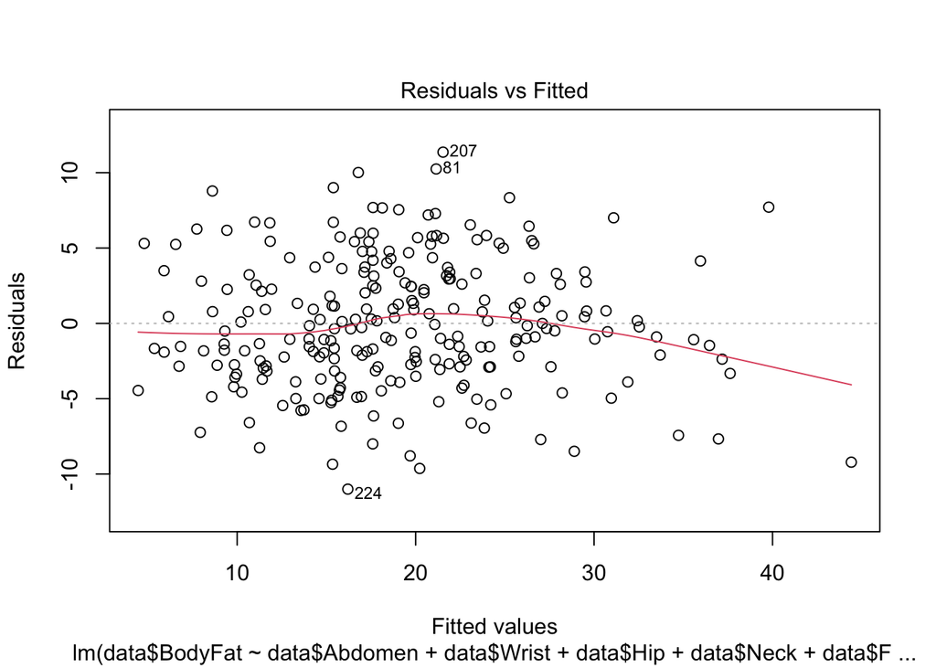

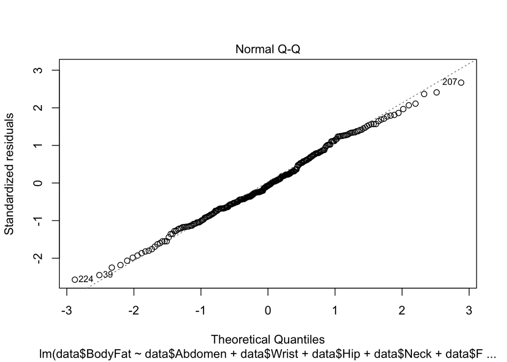

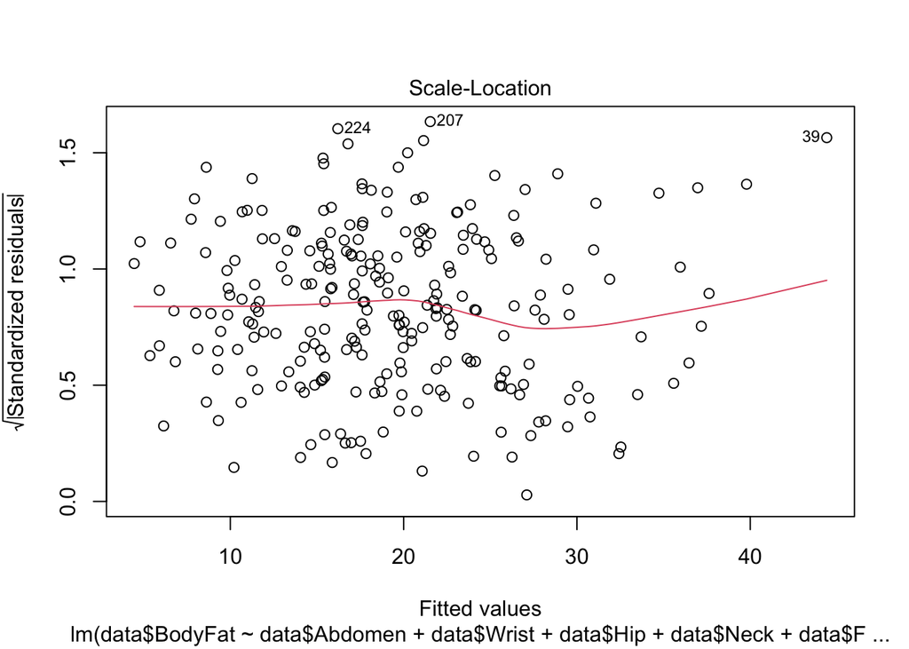

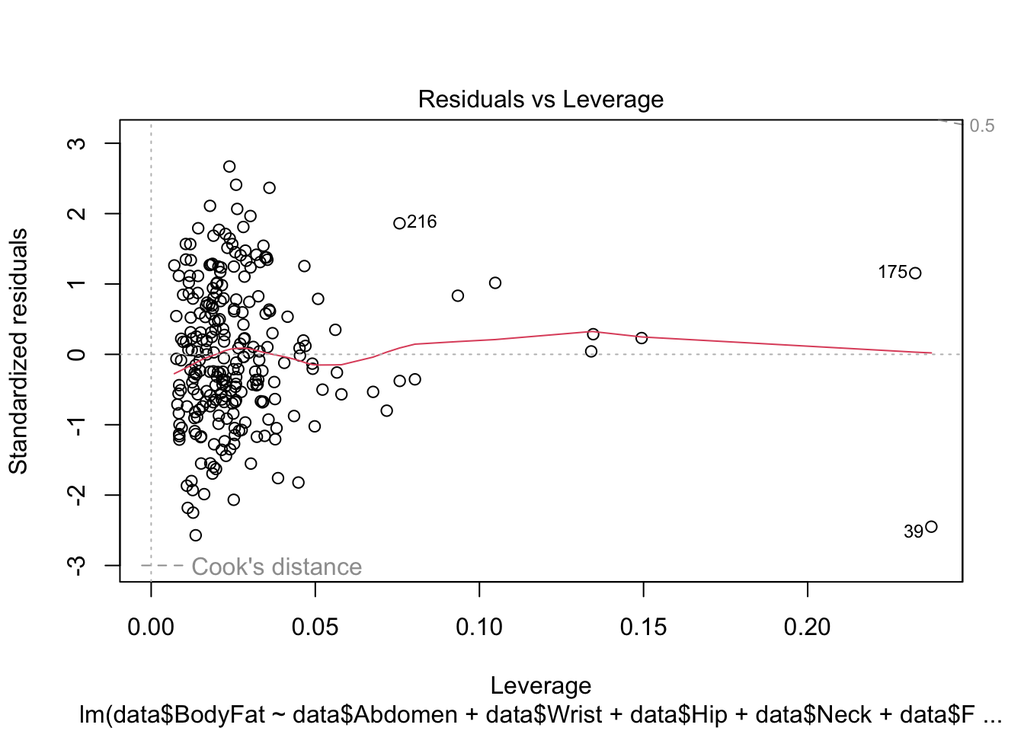

```r
model <- lm(data$BodyFat ~ data$Abdomen + data$Wrist + data$Hip + data$Neck + data$Forearm + data$Age + data$Thigh - 1)

plot(model)
```

The residual and QQ Plot both look fine but not perfect. There are some leverage points and points 39 and 175 have an especially high leverage why I want to exclude them.

```r
new_data <- data[-c(39, 175), ]

new_model <- lm(new_data$BodyFat ~ new_data$Abdomen + new_data$Wrist + new_data$Hip + new_data$Neck + new_data$Forearm + new_data$Age + new_data$Thigh - 1)

summary(new_model)
```

```
##
## Call:
## lm(formula = new_data$BodyFat ~ new_data$Abdomen + new_data$Wrist +
##     new_data$Hip + new_data$Neck + new_data$Forearm + new_data$Age +
##     new_data$Thigh - 1)
##
## Residuals:
##      Min       1Q   Median       3Q      Max
## -10.9772  -2.9431  -0.3793   3.0482  11.0536
##
## Coefficients:
##                  Estimate Std. Error t value Pr(>|t|)
## new_data$Abdomen  0.88216    0.05575  15.823  < 2e-16 ***
## new_data$Wrist   -2.20291    0.46666  -4.721 3.97e-06 ***
## new_data$Hip     -0.31353    0.10805  -2.902  0.00405 **
## new_data$Neck    -0.55249    0.21399  -2.582  0.01041 *
## new_data$Forearm  0.36283    0.22297   1.627  0.10498
## new_data$Age      0.08345    0.02894   2.883  0.00429 **
## new_data$Thigh    0.26710    0.12819   2.084  0.03823 *
## ---
## Signif. codes:  0 '***' 0.001 '**' 0.01 '*' 0.05 '.' 0.1 ' ' 1
##
## Residual standard error: 4.269 on 243 degrees of freedom
## Multiple R-squared:  0.959,  Adjusted R-squared:  0.9579
## F-statistic: 812.7 on 7 and 243 DF,  p-value: < 2.2e-16
```

The insignifance of Forearm in the new model makes me test the new model again with removed Forearm and since there is only a minimal loss on the R values (as seen below) I remove Forearm to make my model simpler again (because we learned that adjusted R squared does not punish complexity as much as other criteria i tend now to make the model a little bit less complex by hand).

```r
new_model2 <- lm(new_data$BodyFat ~ new_data$Abdomen + new_data$Wrist + new_data$Hip + new_data$Neck + new_data$Age + new_data$Thigh - 1)

summary(new_model2)
```

```
##
## Call:
## lm(formula = new_data$BodyFat ~ new_data$Abdomen + new_data$Wrist +
##     new_data$Hip + new_data$Neck + new_data$Age + new_data$Thigh -
##     1)
##
## Residuals:
##      Min       1Q   Median       3Q      Max
## -10.7954  -2.9749  -0.4437   3.0927  11.4332
##
## Coefficients:
##                  Estimate Std. Error t value Pr(>|t|)
## new_data$Abdomen  0.88104    0.05594  15.751  < 2e-16 ***
## new_data$Wrist   -1.96235    0.44412  -4.419  1.5e-05 ***
## new_data$Hip     -0.30195    0.10818  -2.791  0.00567 **
## new_data$Neck    -0.44392    0.20400  -2.176  0.03051 *
## new_data$Age      0.07386    0.02843   2.598  0.00996 **
## new_data$Thigh    0.28894    0.12791   2.259  0.02478 *
## ---
## Signif. codes:  0 '***' 0.001 '**' 0.01 '*' 0.05 '.' 0.1 ' ' 1
##
## Residual standard error: 4.284 on 244 degrees of freedom
## Multiple R-squared:  0.9586, Adjusted R-squared:  0.9576
## F-statistic: 941.3 on 6 and 244 DF,  p-value: < 2.2e-16
```

```r
new_model <- lm(new_data$BodyFat ~ new_data$Abdomen + new_data$Wrist + new_data$Hip + new_data$Neck + new_data$Age + new_data$Thigh - 1)

summary_table <- summary(new_model)$coefficients
ci_table <- confint(new_model)

rownames(summary_table) <- c("Abdomen", "Wrist", "Hip", "Neck", "Age", "Thigh")
colnames(ci_table) <- c("Lower CI", "Upper CI")

summary_table <- cbind(summary_table, ci_table)

summary_table
```

```
##            Estimate Std. Error   t value     Pr(>|t|)    Lower CI    Upper CI
## Abdomen  0.88103988 0.05593710 15.750547 4.875660e-39  0.77085868  0.99122108
## Wrist   -1.96235097 0.44411978 -4.418517 1.495443e-05 -2.83714880 -1.08755314
## Hip     -0.30194837 0.10817969 -2.791174 5.667145e-03 -0.51503358 -0.08886315
## Neck    -0.44392080 0.20400453 -2.176034 3.051256e-02 -0.84575546 -0.04208615
## Age      0.07385662 0.02843328  2.597541 9.960087e-03  0.01785061  0.12986263
## Thigh    0.28893770 0.12791375  2.258848 2.477625e-02  0.03698164  0.54089376
```

Overall the fit of my model is fine as the R values suggest. Taking out the Intercept really improved the models performance as I also tried more complex models with the intercept and it always performed much worse than any model without an intercept. In the context Abdomen really estimates the BodyFat best because most fat lies there. Thigh is basically the same only that it is not as significant as the Abdomen. Age is good since people tend to get a little bit less fit as they get older which contributes to a higher bodyfat percentage. Hip is negative as it kind of complements the abdomen. Abdomen size is not only conditional on bodyfat but also other factors which also contributes to the Hip. So i guess Hip subtracts the part of abdomen out which is not due to bodyfat but other factors. Neck is kinda unclear how it contributes but I think a larger neck is a size for overall much muscle which contributes also to less bodyfat.

The data points I removed had so much more leverage than all the other data points that I think I get a more balanced data set by removing them.